$$ \require{color} %https://vega.github.io/vega/docs/schemes/#category10 \definecolor{C1}{RGB}{31,119,180} \definecolor{C2}{RGB}{255,127,14} \definecolor{C3}{RGB}{44,160,44} \definecolor{C4}{RGB}{214,39,40} \definecolor{C5}{RGB}{148,103,189} \definecolor{C6}{RGB}{140,86,75} \definecolor{C7}{RGB}{227,119,194} \definecolor{C8}{RGB}{127,127,127} \definecolor{C9}{RGB}{188,189,34} \definecolor{C10}{RGB}{23,190,207} \def\CPsi#1{{\color{C1}\Psi #1}} $$

# 1 The Wave Function

## 1.4 Normalisation

## Problem 1.4

At time $t = 0$ a particle is represented by the wave function $$ \CPsi{(x,0)} = \begin{cases} {\color{C2}A(x/a)}, & 0\leq x\leq a,\\ {\color{C3}A(b - x) / (b-a)}, & a\leq x\leq b,\\ 0 & \text{otherwise}, \end{cases} $$

where $A$, $a$, and $b$ are (positive) constants.

### a) Find A

For a probability density function, the total area under the curve must be 1, or more specifically $$\int\limits_{-\infty}^{+\infty}{|\CPsi{(x, t)}|^2}dx = 1.$$

To find $A$ we need to rearrange the above to become an expression in terms of $A$. To begin with, we take the fact that $|\CPsi{}|^2 = \CPsi{^*} \CPsi{}$, where $\CPsi{^*}$ is the complex conjugate of $\CPsi{}$. So now we can see that we in fact have the following expression, $$\int\limits_{-\infty}^{+\infty}{\CPsi{^*} \CPsi{}}dx = 1.$$

We are given $\CPsi{(x, 0)}$, which we can use to get a value of $A$ at $t=0$. Note, it was demonstrated in the text that $$ \frac{d}{dt} \int\limits_{-\infty}^{+\infty}{|\CPsi{(x, t)}|^2}dx = 0, $$ so finding $A$ at $t=0$ gives us a normalising factor for all times.

Let's first consider expanding the integrand $\CPsi{^*} \CPsi{}$. On the authority of [@leslietownes](https://chat.stackexchange.com/transcript/message/57607173#57607173), $\CPsi{^*}$ is simply $\CPsi{}$, because there are no complex numbers involved. So we infact have $$ \CPsi{^2} = \begin{cases} \color{C2}{A^2(x^2/a^2)} , & 0\leq x\leq a,\\ \color{C3}{A(\frac{(b - x)}{(b-a)})^2} , & a\leq x\leq b,\\ 0 & \text{otherwise}. \end{cases} $$

Notice that $\Psi$ is piecewise, so we can rewrite our probability density function as a sum of integrals over the different domains. $$ \int\limits_{-\infty}^{+\infty}{\CPsi{^*} \CPsi{}}dx,$$ becomes$$ \int\limits_{-\infty}^{+\infty}{\CPsi{^2}}dx,$$ which in turn is equivalent to $$ {\color{C2}\int\limits_{0}^{a}{A^2\frac{x^2}{a^2}}dx} + % {\color{C3}\int\limits_{a}^{b}{\left(\frac{A(b-x)}{(b-a)}\right)^2}dx }= 1. \label{eq:int_sum}$$

On the left side we have an elementray integral, namely $${\color{C2}\int\limits_{0}^{a}{A^2\frac{x^2}{a^2}}dx},$$ which we know from our [integral tables](http://integral-table.com/) is just, $$ \color{C2}{(\frac{A}{a})^2\big[\frac{x^3}{3}\big]_0^a}. $$ This evaluates nicely to, $$ {\color{C2}(\frac{A}{a})^2\big[\frac{a^3}{3}\big]} = {\color{C2}A^2\frac{a}{3}}. $$

Meanwhile for the right side integral, we need to stop and listen to Father Ted.

> Do NOT unfactor things that are beautifully factored. That is one of the most basic mistakes/sins that students make. [`@TedShifrin`](https://chat.stackexchange.com/transcript/message/57613085#57613085)

Now ask ourselves: *"self, how can I get these constants out of my integral?"*.

$${\color{C3}\left(\frac{A(b-x)}{(b-a)}\right)^2},$$

can become

$${\color{C3}A^2 \frac{b^2 -2bx + x^2}{b^2 -2ab + a^2}},$$

Which in turn is equivalent to,

$$ {\color{C3} \left(\frac{A^2}{b^2 -2ab + a^2}\right)(b^2-2bx+x^2) } $$

So the right integral becomes, $$ {\color{C3} \left(\frac{A^2}{b^2 -2ab + a^2}\right) \int\limits_a^b{(b^2-2bx+x^2)}dx. } $$ We can solve the integral for each term in the polynomial to get. $$ {\color{C3} \left(\frac{A^2}{b^2 -2ab + a^2}\right) % \left(b^2\left[x\right]_a^b -b\left[x^2\right]_a^b +\frac{1}{3}\left[x^3\right]_a^b \right). } $$

Now we evaluate the at the boundries, to get $$ {\color{C3} \left(\frac{A^2}{b^2 -2ab + a^2}\right) % \left( b^2\left[b - a\right] -b\left[b^2 - a^2\right] +\frac{1}{3}\left[b^3 - a^3\right] \right). } $$ By collecting like terms to simplify, this can become $$ {\color{C3} \left(\frac{A^2}{b^2 -2ab + a^2}\right) % \left( \frac{b^3 + 3a^2b-3ab^2 - a^3}{3} \right). } $$

With the help of [wolfram alpha](https://www.wolframalpha.com/input/?i=b%5E3+%2B+3a%5E2b-3ab%5E2+-+a%5E3) we can observe $$b^3 + 3a^2b-3ab^2 - a^3 = -(a-b)^3,$$ So we can simplify further to get, $$ {\color{C3} \left(\frac{A^2}{b^2 -2ab + a^2}\right) % \left( \frac{-(a-b)^3}{3} \right), } $$ or equivalently, $$ {\color{C3} \frac{ A^2(b-a)^3}{3(b-a)^2} }, $$ and then, $$ {\color{C3} \frac{1}{3}A^2(a-b)}, $$ provided we specify that $a-b \neq 0$.

So combining our two expressions we get $$ {\color{C2}A^2\frac{a}{3}} + {\color{C3} \frac{1}{3}A^2(a-b)} = 1, $$ Notice we can take out $\frac{A^2}{3}$ to get, $$ \frac{1}{3}A^2 (a + a-b) = 1. $$ Rearranging, to get an expression in terms of $A$ yeilds, $$ \begin{align} A^2 &= \frac{3}{(2a-b)} \\ A &= \sqrt{\frac{3}{(2a-b)}}. \end{align} $$ Where $2a\neq b$, and $a\neq b$.

### b) Sketch Ψ(x, 0)

```python
# sketch the function
import matplotlib.pyplot as plt
import numpy as np

a = 1+np.random.rand()
b = a + np.random.rand()

A =  np.sqrt(3/(2*a-b))

x = np.linspace(0 - (b*.05), b*1.05, 500)

psi_0 = np.zeros_like(x)

x0 = (x <= a)
x1 = (x > a) & (x <= b)
xe = (x < 0) | (x > b)

psi_0[x0] = A * (x[x0] / a)
psi_0[x1] = A * ((b -  x[x1])/ (b-a))
psi_0[xe] = 0
```

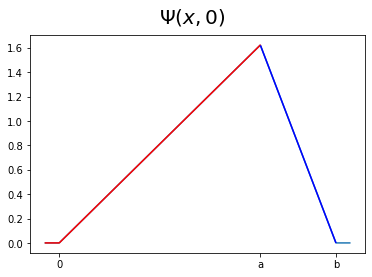

```python
fig, ax = plt.gcf(), plt.gca()
fig.suptitle(r'$\Psi(x, 0)$', fontsize=20) # Add the text/suptitle to figure
ax.plot(x, psi_0);
ax.plot(x[x0], psi_0[x0], 'r')
ax.plot(x[x1], psi_0[x1], 'b')
#plt.plot(x[xe], psi_0[xe], '.5')
ax.set_xticks([0, a,b]);
ax.set_xticklabels([0, 'a', 'b']);
```

### c) Where is the particle most likely to be found, at t = 0?

Why, the particle is most likely to be found at position $a$, this is the maximum value of $\Psi$ at $t=0$.

### e) What is the epected value of $x$

```python
from sympy.abc import a,b
from sympy import simplify

A = 2/b
I_1 = (a**2)/3
I_21 = ((b**3) - (b * (a**2))) /2
I_22 = ((b**3) - (a**3)) / 3
I_2c = 1 / (b-a)
equation = (
    A * (
        I_1 + (I_21 + I_22) * I_2c
    )
)

equation
```

$\displaystyle \frac{2 \left(\frac{a^{2}}{3} + \frac{- \frac{a^{3}}{3} - \frac{a^{2} b}{2} + \frac{5 b^{3}}{6}}{- a + b}\right)}{b}$

```python
simplify(equation)
```

$\displaystyle \frac{4 a^{2} + 5 a b + 5 b^{2}}{3 b}$

## * Problem 1.5

Consider the wave function $$ \Psi(x,t) = Ae^{-\lambda |x|}e^{-i\omega t}, $$ where $A$, $\lambda$, and $\omega$ are positive real constants.

### a) Normalise Ψ

To determine $A$ we need to find an expression for the total area under $|\Psi(x,0)|^2$, which we know is defined to be 1. While $\Psi$ is a complex function, $|\Psi|^2 = \Psi^*\Psi$, (where $\Psi^*$ is the complex conjugate of $\Psi$) is real, and non-negative.

To begin, $$ \int\limits_{-\infty}^{+\infty}{|\Psi(x,t)|^2}dx = 1. $$

Procede by expanding,$|\Psi|^2 = \Psi^*\Psi$, to get $$ \begin{align} \Psi^*\Psi &= Ae^{-\lambda |x|}e^{-i\omega t} \cdot Ae^{-\lambda |x|}e^{i\omega t}\\ &= A^2 e^{-2\lambda 2|x|- 2\omega 2t}\\ \end{align} $$

Now, let's try to simplify. We are taking the integral with respect to $x$, so we can treat $t$ as a constant. If we let $\mu = \frac{\omega t}{\lambda}$, we can rewrite the above expression as, $$A^2 e^{\lambda^2 x^2 - \lambda^2 \mu^2}.$$ This in turn can become, $$A^2 e^{\lambda^2(x - \mu)^2},$$ an expression that is very familiar in light of the previous excercises.

Now, we can consider the probability density function. So returning to our integral, we can write, $$ \int\limits_{-\infty}^{+\infty}{A^2e^{\lambda^2(x - \mu)^2}}dx = 1. $$

So now we have the Gaussian Integral again. Hence, $$ A^2 \int\limits_{-\infty}^{+\infty}{e^{\lambda^2(x - \mu)^2}}dx =1 \implies A^2 \sqrt{\frac{\pi}{\lambda^2}} = 1\\ A^2 = \sqrt{\frac{\lambda^2}{\pi}}\\ A = \sqrt[^4]{\frac{\lambda^2}{\pi}}\\ A = \sqrt{\frac{\lambda}{\sqrt{\pi}}}\\ $$

### b) Determine expectation values of $x$ and $x^2$

Now we can expand $y + \mu$ to get two integrals, $$ \int\limits_{-\infty}^{+\infty} {(y+\mu) e^{\lambda^2y^2}}dy = \\ \int\limits_{-\infty}^{+\infty} {y e^{\lambda^2y^2}}dy + \mu \int\limits_{-\infty}^{+\infty} { e^{\lambda^2y^2}}dy $$

So for completness, recall we set $\mu = \frac{\omega t}{\lambda}$, so $$<x> = \frac{\omega t}{\lambda}.$$

Now for $<x^2>$ we begin in a similar fashion, $$<x^2> = \int\limits_{-\infty}^{+\infty} {x^2 A^2e^{\lambda^2(x - \mu)^2}}dx.$$

Again we simplify our integral, bringing out $A^2$ and proceding with a subsititution, in fact the same one. So we let $y = x-\mu$, and now $x^2$ becomes $(y+\mu)^2$. This expands to $y^2 + 2\mu y + \mu^2$. Thus we are dealing with three integrals (one for each term of the polynomial). So, cutting to the chase our three integrals are, $$ \begin{align} I_{y^2} &= \int\limits_{-\infty}^{+\infty} {y^2 e^{\lambda^2y^2}}dy\\ I_{2\mu y}&= 2\mu \int\limits_{-\infty}^{+\infty} {y e^{\lambda^2y^2}}dy &&= 0\\ I_{\mu^2} &= \mu^2 \int\limits_{-\infty}^{+\infty} {e^{\lambda^2y^2}}dy &&= \mu^2 \sqrt{\frac{\pi}{\lambda^2}}. \end{align} $$

The last two integrals we have already solved in the previous example. Likewise, the first integral is by now familiar. To solve it we use the integration by parts pattern, $$\int{UdV} = UV - \int{VdU}.$$ We know how to differentiate an exponential, so we let $$V = e^{\lambda^2 y^2},$$ then, by the chain rule we get, $$dV = 2\lambda^2 y e^{\lambda^2 y^2}.$$ Plugging $dV$ back into our integral, we see that we need $$U = \frac{y}{2\lambda^2},$$ and so we must also have $$dU = \frac{1}{2\lambda^2}.$$